# Power Analysis

ChatGPT 4o

2025-01-21

## 1 起源

功效分析（Power Analysis）最早由统计学家Jerzy Neyman和Egon Pearson在20世纪30年代提出，用于评估统计检验的能力，即发现研究中实际存在的效应的概率。随着统计理论的发展，功效分析成为实验设计和样本量计算中的重要组成部分，被广泛应用于医学、心理学、社会科学等领域，用于确保研究结果的可靠性和效能。

## 2 原理

功效分析的核心原理是通过量化统计检验的检验效能（Power），来评估实验设计在特定效应大小、样本量和显著性水平下，正确拒绝原假设的概率。功效分析涉及以下几个重要概念：

- **统计功效（Power）**：正确拒绝虚无假设（即原假设为假）时的概率，通常设定为0.8或更高，表示有80%的机会发现实际存在的效应。
- **显著性水平（Alpha, $\alpha$**：错误拒绝原假设（即犯I型错误）的概率，通常设定为0.05。
- **效应量（Effect Size）**：表示实际效应的大小，通常用Cohen’s d、相关系数r等来衡量。效应量越大，越容易在样本中检测到差异。
- **样本量（Sample Size）**：样本量的大小直接影响功效，样本量越大，越有可能检测到实际存在的效应。

功效分析通常通过以下方法进行：

- **前验功效分析（A Priori Power Analysis）**：在研究开始前确定合适的样本量，以确保功效达到预期水平。
- **后验功效分析（Post Hoc Power Analysis）**：在研究完成后计算实际的统计功效，用于评估结果的可靠性。
- **敏感性分析（Sensitivity Analysis）**：给定样本量和显著性水平，计算能够检测到的最小效应量。

功效分析的计算基于统计检验的假设分布，例如t检验、ANOVA、线性回归等。

### 不同功效分析的计算公式

- **t检验样本量计算**：
  $$n = \frac{(Z_{1-\alpha/2} + Z_{1-\beta})^2 \cdot 2 \cdot
  \sigma^2}{\Delta^2}$$
  其中，$Z_{1-\alpha/2}$ 和 $Z_{1-\beta}$ 为标准正态分布的分位数，$\sigma$ 为总体标准差，$\Delta$ 为效应量。
- **比率检验样本量计算**：
  $$n = \frac{(Z_{1-\alpha/2} \sqrt{2p(1-p)} + Z_{1-\beta} \sqrt{p_1(1-p_1)
  + p_2(1-p_2)})^2}{(p_1 - p_2)^2}$$
  其中，$p_1$ 和 $p_2$ 为两组的比例，$p$ 为总体比例的估计值。
- **效应量（Cohen’s d）**：
  $$d = \frac{\mu_1 - \mu_2}{\sigma}$$
  其中，$\mu_1$ 和 $\mu_2$ 为两组的均值，$\sigma$ 为标准差。
- **功效（Power）计算**：功效是正确拒绝虚无假设的概率，计算公式为：
  $$1 - \beta = P(\text{拒绝 } H_0 | H_1 \text{ 为真})$$
  其中，$\beta$ 表示犯II型错误的概率。

## 3 适用范围

功效分析适用于以下情况：

- **实验设计和样本量确定**：在研究设计阶段，通过功效分析确定合适的样本量，以保证研究具有足够的检验效能。
- **研究结果的可靠性评估**：在研究结束后，计算功效来评估统计分析结果的可靠性和稳健性。
- **效应大小和显著性水平的评估**：在研究计划中评估所需的效应大小和显著性水平，以达到理想的检验效能。

## 4 应用情境

功效分析在多个领域中有广泛的应用，例如：

- **医学和公共卫生**：用于临床试验中样本量的确定，确保能够检测到治疗效果或药物的差异。
- **心理学和社会科学**：在实验研究中确定样本量，确保实验设计具有足够的统计检验能力。
- **市场研究**：用于评估营销活动的影响，确定样本量以保证能够检测到显著的市场变化。

## 5 优缺点

### 优点

- **提高研究的可靠性**：通过合理的样本量设计，功效分析可以提高研究结果的可靠性和稳健性。
- **资源优化**：确保样本量足够的同时避免过多，节省时间和资金成本。
- **减少I型和II型错误**：合理的功效分析可以降低犯I型错误和II型错误的概率，保证结果的科学性。

### 缺点

- **复杂性高**：功效分析需要对研究设计、效应量和统计检验有深入了解，计算较为复杂。
- **依赖参数估计**：功效分析的结果依赖于对效应量等参数的估计，如果估计不准确，功效计算的结果可能偏差较大。
- **不适用于所有情况**：功效分析主要适用于实验性研究，对于探索性研究或观察性研究，功效分析的作用较为有限。

## 6 在R中的实现及结果解释

在R中，可以使用`pwr`包进行功效分析，以下是一个实现功效分析的示例：

```r
# 加载必要的包
library(pwr)

# 示例：进行t检验的前验功效分析，计算样本量
# 假设效应量为0.5，显著性水平为0.05，功效为0.8
result <- pwr.t.test(d = 0.5, sig.level = 0.05, power = 0.8, type = "two.sample")

# 输出所需样本量
print(result)
```

```
##
##      Two-sample t test power calculation
##
##               n = 63.76561
##               d = 0.5
##       sig.level = 0.05
##           power = 0.8
##     alternative = two.sided
##
## NOTE: n is number in *each* group
```

```r
summary(result)
```

```
##             Length Class  Mode
## n           1      -none- numeric
## d           1      -none- numeric
## sig.level   1      -none- numeric
## power       1      -none- numeric
## alternative 1      -none- character
## note        1      -none- character
## method      1      -none- character
```

```r
str(result)
```

```
## List of 7
##  $ n          : num 63.8
##  $ d          : num 0.5
##  $ sig.level  : num 0.05
##  $ power      : num 0.8
##  $ alternative: chr "two.sided"
##  $ note       : chr "n is number in *each* group"
##  $ method     : chr "Two-sample t test power calculation"
##  - attr(*, "class")= chr "power.htest"
```

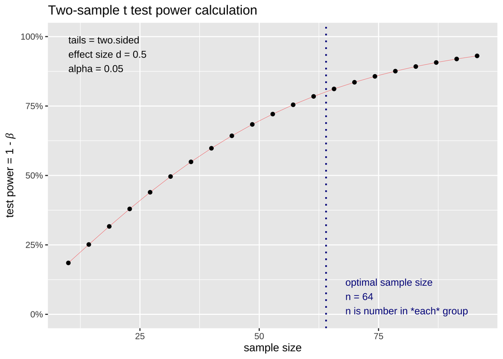

```r
# 绘制功效分析图
plot(result)
```

### 结果的可视化

功效分析的结果可以通过功效曲线图进行可视化，以便直观地理解样本量与统计功效之间的关系。

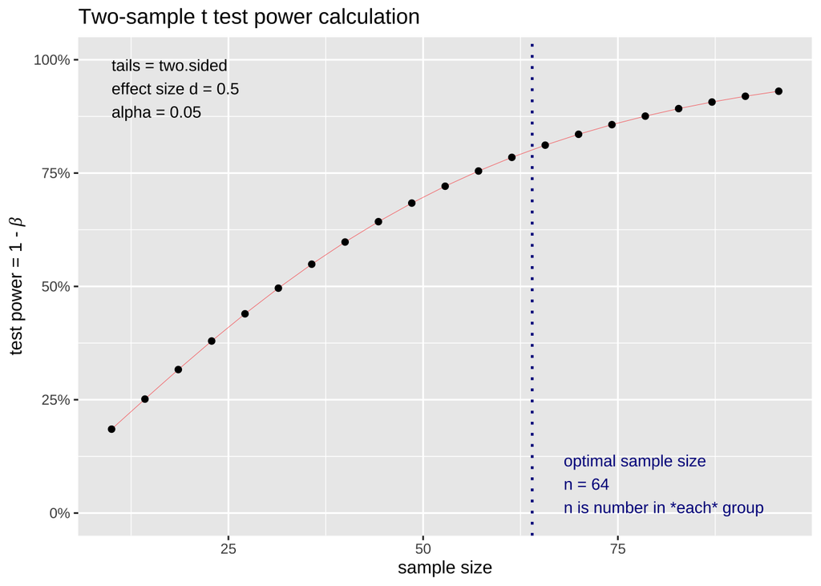

```r
# 绘制功效分析图
plot(result)
```

上述代码生成功效分析曲线，其中横轴为样本量，纵轴为功效值。通过观察曲线，可以直观了解样本量对功效的影响，以及在不同样本量下达到特定功效的可能性。

## 7 小结

- 功效分析是一种用于确定样本量和评估统计检验能力的工具，在医学、心理学和社会科学等领域有着重要的应用。
- 适用于研究设计阶段确定样本量，以及研究结束后评估结果的可靠性。
- 具有提高研究可靠性、优化资源和减少错误概率的优点，但需要对研究设计和参数有深入了解，且不适用于所有类型的研究。
- 可以通过R中的`pwr`包实现功效分析，并结合功效曲线图直观展示结果。
- 功效分析在确保研究具有足够的统计效能、避免资源浪费方面具有重要意义，是科学研究设计中的关键步骤。